# 02_tra_rot_gli_mir

## 02_tra_rot_gli_mir

#### Question

1. There are 4 basic transformations in Frieze groups:
   - Translation
   - Rotation (by 180$^\circ$)
   - Glide reflection (reflect vertically then translate horizontally)
   - Mirror (reflect horizontally)

   Label the four visual representations below:

## Transformation 1

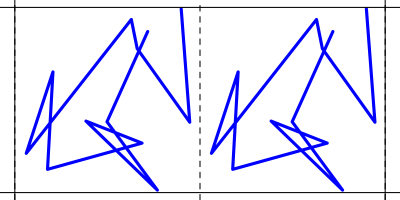

## Transformation 2

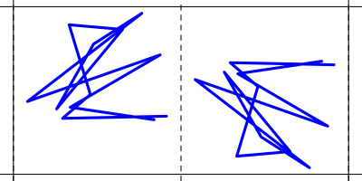

## Transformation 3

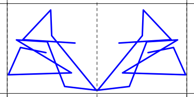

## Transformation 4

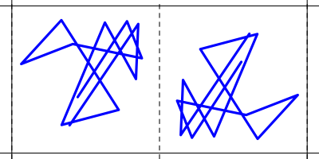

#### Question

2. There are 4 basic transformations in Frieze groups:
   - Translation
   - Rotation (by 180$^\circ$)
   - Glide reflection (reflect vertically then translate horizontally)
   - Mirror (reflect horizontally)

   Label the four visual representations below:

## Transformation 1

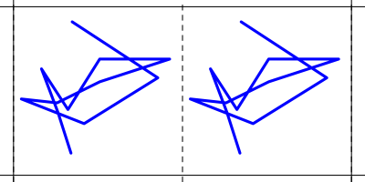

## Transformation 2

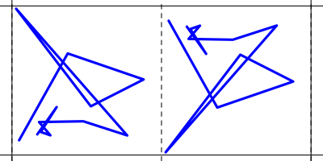

## Transformation 3

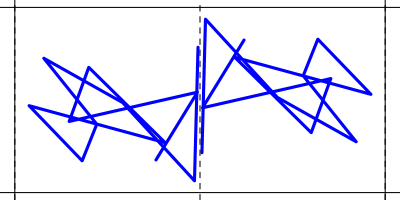

## Transformation 4

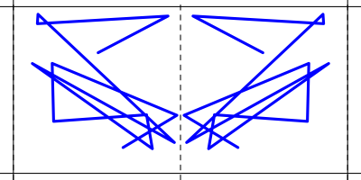

#### Question

3. There are 4 basic transformations in Frieze groups:
   - Translation
   - Rotation (by 180$^\circ$)
   - Glide reflection (reflect vertically then translate horizontally)
   - Mirror (reflect horizontally)

   Label the four visual representations below:

## Transformation 1

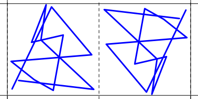

## Transformation 2

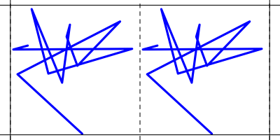

## Transformation 3

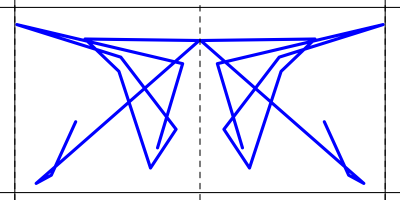

## Transformation 4

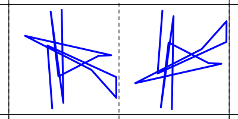

#### Question

4. There are 4 basic transformations in Frieze groups:
   - Translation
   - Rotation (by 180$^\circ$)
   - Glide reflection (reflect vertically then translate horizontally)
   - Mirror (reflect horizontally)

   Label the four visual representations below:

## Transformation 1

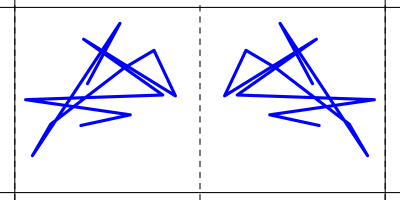

## Transformation 2

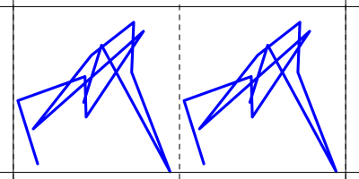

## Transformation 3

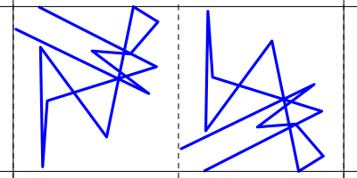

## Transformation 4

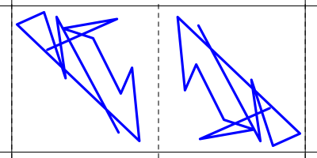

#### Question

5. There are 4 basic transformations in Frieze groups:
   - Translation
   - Rotation (by 180$^\circ$)
   - Glide reflection (reflect vertically then translate horizontally)
   - Mirror (reflect horizontally)

   Label the four visual representations below:

## Transformation 1

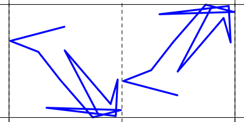

## Transformation 2

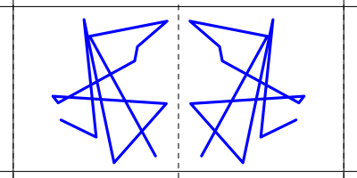

## Transformation 3

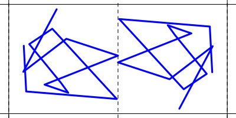

## Transformation 4

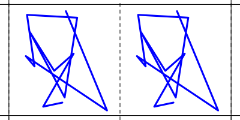

#### Question

6. There are 4 basic transformations in Frieze groups:
   - Translation
   - Rotation (by 180$^\circ$)
   - Glide reflection (reflect vertically then translate horizontally)
   - Mirror (reflect horizontally)

   Label the four visual representations below:

## Transformation 1

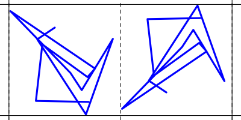

## Transformation 2

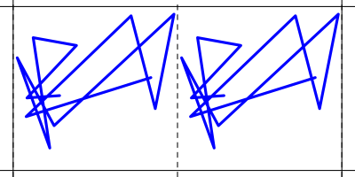

## Transformation 3

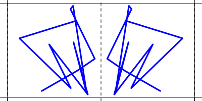

## Transformation 4

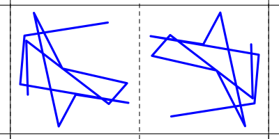

#### Question

7. There are 4 basic transformations in Frieze groups:
   - Translation
   - Rotation (by 180$^\circ$)
   - Glide reflection (reflect vertically then translate horizontally)
   - Mirror (reflect horizontally)

   Label the four visual representations below:

## Transformation 1

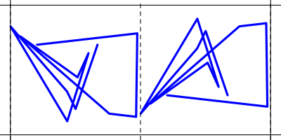

## Transformation 2

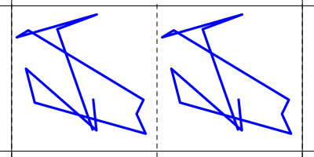

## Transformation 3

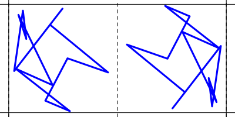

## Transformation 4

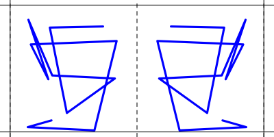

#### Question

8. There are 4 basic transformations in Frieze groups:
   - Translation
   - Rotation (by 180$^\circ$)
   - Glide reflection (reflect vertically then translate horizontally)
   - Mirror (reflect horizontally)

   Label the four visual representations below:

## Transformation 1

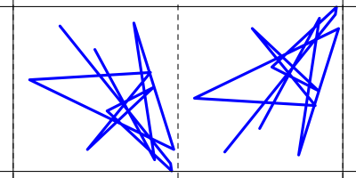

## Transformation 2

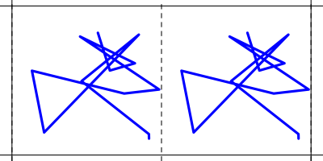

## Transformation 3

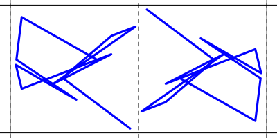

## Transformation 4

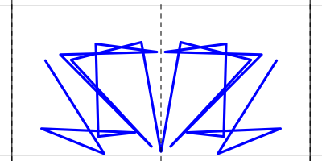